# Modelos bayesianos jerárquicos

Jesica Charaf, Gonzalo Berasaluce e Ignacio Spiousas

2024-05-11

## Exploración de datos

Modificamos los datos para ver las medias por artista:

```r
spotify <- spotify %>%
  select(artist, title, popularity) %>%
  mutate(artist = fct_reorder(artist, popularity, .fun = 'mean'))

artist_means <- spotify %>%
  group_by(artist) %>%
  summarize(count = n(), popularity = mean(popularity))
```

Los artistas más y menos populares:

```r
artist_means %>%
  slice(1:2, 43:44)
```

```
## # A tibble: 4 × 3
##   artist        count popularity
##   <fct>         <int>      <dbl>
## 1 Mia X             4       13.2
## 2 Chris Goldarg    10       16.4
## 3 Lil Skies         3       79.3
## 4 Camilo            9       81
```

## Modelo full pooleado

Tenemos de 2 a 40 canciones por artista:

```r
artist_means %>%
  summarize(min(count), max(count))
```

```
## # A tibble: 1 × 2
##   `min(count)` `max(count)`
##          <int>        <int>
## 1            2           40
```

La estimación no paramétrica de la densidad tiene esta pinta:

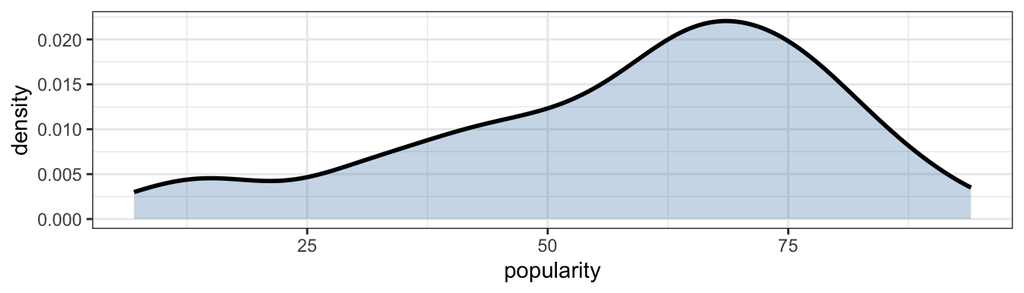

```r
ggplot(spotify, aes(x = popularity)) +
  geom_density(linewidth = 1, fill = "steelblue", alpha = .3) +
  theme_bw()
```

Ahora vamos a ajustar el modelo full pooleado:

```r
spotify_complete_pooled <- stan_glm(
  popularity ~ 1,
  data = spotify, family = gaussian,
  prior_intercept = normal(50, 2.5, autoscale = TRUE),
  prior_aux = exponential(1, autoscale = TRUE),
  chains = 4, iter = 5000*2, seed = 84735)
```

Si bien en el texto dice que el prior de $\mu$ es $\mu \sim N(50, 52^2)$, podemos ver que en el código dice `normal(50, 2.5, autoscale = TRUE)`. Esto es porque el autor aprovecha la opción `autoscale` de `stan_glm()`. En el caso del prior gaussiano esto significa que $\sigma$ es $2.5 \times S_y$:

```r
round(2.5 * sd(spotify$popularity))
```

```
## [1] 52
```

`prior_aux` por defecto si el prior de intercept es normal es $\sigma$. Para setear el `prior_aux` también aprovecha la opción `autoscale` de `stan_glm()`. Esto significa, para el caso exponencial, que el prior para $\sigma$ es $1 / S_y$:

```r
round(1/sd(spotify$popularity), digits = 3)
```

```
## [1] 0.048
```

De hecho, si chequeamos los priors podemos ver los valore ajustados:

```r
# Get prior specifications
prior_summary(spotify_complete_pooled)
```

```
## Priors for model 'spotify_complete_pooled'
## ------
## Intercept (after predictors centered)
##   Specified prior:
##     ~ normal(location = 50, scale = 2.5)
##   Adjusted prior:
##     ~ normal(location = 50, scale = 52)
##
## Auxiliary (sigma)
##   Specified prior:
##     ~ exponential(rate = 1)
##   Adjusted prior:
##     ~ exponential(rate = 0.048)
## ------
## See help('prior_summary.stanreg') for more details
```

Y ver el posterior summary:

```r
complete_summary <- tidy(spotify_complete_pooled,
                         effects = c("fixed", "aux"),
                         conf.int = TRUE, conf.level = 0.80)
complete_summary
```

```
## # A tibble: 3 × 5
##   term        estimate std.error conf.low conf.high
##   <chr>          <dbl>     <dbl>    <dbl>     <dbl>
## 1 (Intercept)     58.4     1.10      57.0      59.8
## 2 sigma           20.7     0.776     19.7      21.7
## 3 mean_PPD        58.4     1.57      56.4      60.4
```

Las estimaciónes del modelo en relación a las medias por artista:

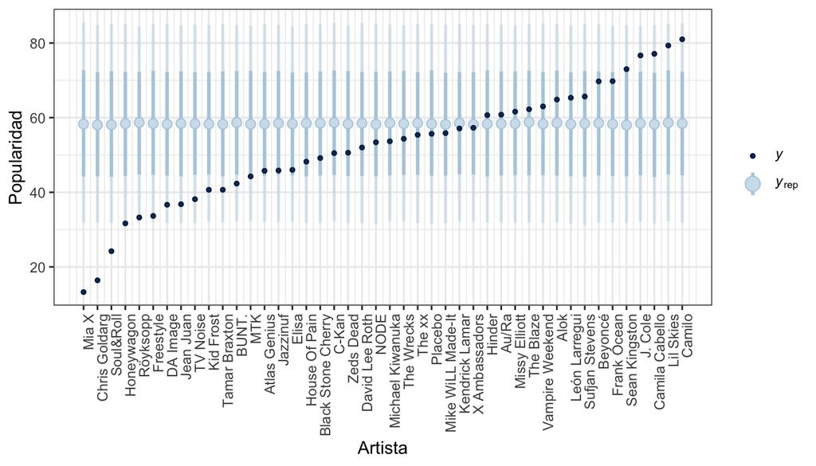

```r
set.seed(84735)
predictions_complete <- posterior_predict(spotify_complete_pooled,
                                          newdata = artist_means)

ppc_intervals(artist_means$popularity, yrep = predictions_complete,
              prob_outer = 0.80) +
  ggplot2::scale_x_continuous(labels = artist_means$artist,
                              breaks = 1:nrow(artist_means)) +
  theme_bw() +
  xaxis_text(angle = 90, hjust = 1)  +
  labs(x = "Artista", y = "Popularidad")
```

Las estimaciones promedio por artista van a ser todas iguales e iguales a las estimaciones por canción, ya que todas las estimaciones son iguales.

$$E(\mu|y) \approx 58.39$$

## Modelo sin poolear

Ahora vamos a conservar todos los artistas por separado.

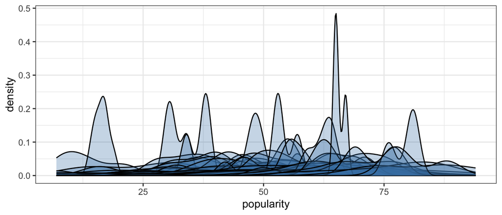

```r
ggplot(spotify, aes(x = popularity, group = artist)) +
  geom_density(linewidth = .5, fill = "steelblue", alpha = .3) +
  theme_bw()
```

$$Y_{ij}|\mu_j,\sigma \sim N(\mu, \sigma^2)$$

Ahora definimos el modelo. Lo único que cambia es que agregamos `artist` como predictor (y con el `-1` le sacamos el intercept). Fijensé que ahora en lugar de `prior_intercept` dice sólo `prior` y por eso es que en la definici’on del libro dice que $\mu_j \sim N(50, S^2_j)$.

```r
spotify_no_pooled <- stan_glm(
  popularity ~ artist - 1,
  data = spotify, family = gaussian,
  prior = normal(50, 2.5, autoscale = TRUE),
  prior_aux = exponential(1, autoscale = TRUE),
  chains = 4, iter = 5000*2, seed = 84735)
```

Acá también podemos chequear los priors:

```r
# Get prior specifications
prior_summary(spotify_no_pooled)
```

```
## Priors for model 'spotify_no_pooled'
## ------
##
## Coefficients
##   Specified prior:
##     ~ normal(location = [50,50,50,...], scale = [2.5,2.5,2.5,...])
##   Adjusted prior:
##     ~ normal(location = [50,50,50,...], scale = [484.78,309.30,434.23,...])
##
## Auxiliary (sigma)
##   Specified prior:
##     ~ exponential(rate = 1)
##   Adjusted prior:
##     ~ exponential(rate = 0.048)
## ------
## See help('prior_summary.stanreg') for more details
```

Y ahora podemos ver los ajustes por artista con respecto a la $\bar{y}_j$:

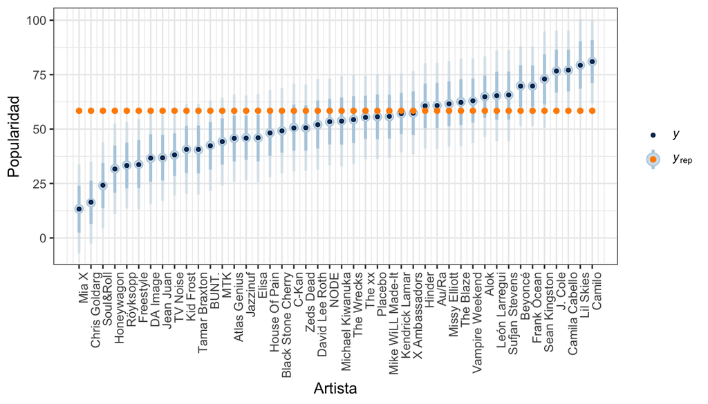

```r
# Simulate the posterior predictive models
set.seed(84735)
predictions_no <- posterior_predict(
  spotify_no_pooled, newdata = artist_means)

# Plot the posterior predictive intervals
ppc_intervals(artist_means$popularity, yrep = predictions_no,
              prob_outer = 0.80) +
  ggplot2::scale_x_continuous(labels = artist_means$artist,
                              breaks = 1:nrow(artist_means)) +
  theme_bw() +
  geom_point(x = 1:nrow(artist_means), y = complete_summary$estimate[1], color = "darkorange") +
  xaxis_text(angle = 90, hjust = 1) +
  labs(x = "Artista", y = "Popularidad")
```

Qué pasa si poneoms el mismo prior para $\mu$ pero con menor dispersión. Pongamos $0.1$ en la función que sería equivalente a decir que $\mu_j \sim N(50, 2)$:

```r
spotify_no_pooled_smallsigma <- stan_glm(
  popularity ~ artist - 1,
  data = spotify, family = gaussian,
  prior = normal(50, .1, autoscale = TRUE),
  prior_aux = exponential(1, autoscale = TRUE),
  chains = 4, iter = 5000*2, seed = 84735)
```

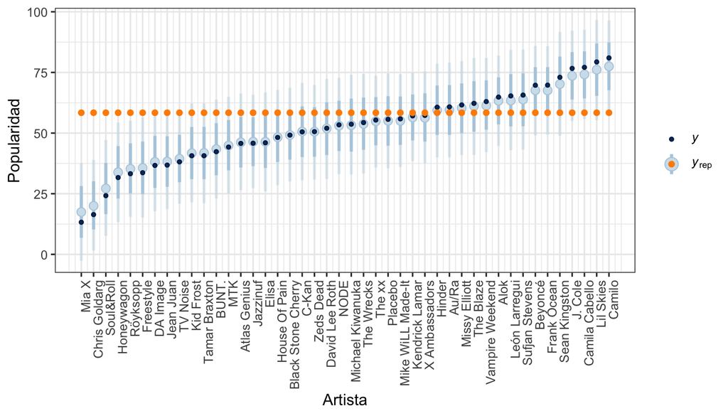

```r
# Simulate the posterior predictive models
set.seed(84735)
predictions_no <- posterior_predict(
  spotify_no_pooled_smallsigma, newdata = artist_means)

# Plot the posterior predictive intervals
ppc_intervals(artist_means$popularity, yrep = predictions_no,
              prob_outer = 0.80) +
  ggplot2::scale_x_continuous(labels = artist_means$artist,
                              breaks = 1:nrow(artist_means)) +
  theme_bw() +
  geom_point(x = 1:nrow(artist_means), y = complete_summary$estimate[1], color = "darkorange") +
  xaxis_text(angle = 90, hjust = 1) +
  labs(x = "Artista", y = "Popularidad")
```

Efectivamente vemos que los $\mu_j$ quedan más cerca de $50$ y ya no son la media de las observaciones para ese artista.

## El modelo jerárquico

Ahora tenemos básicamente tres capas de modelado:

$$\begin{array}
_Capa 1: Y_{ij}|\mu_j,\sigma_y &\sim& Modela \,\, cómo \,\,
varía \,\, la \,\, popularidad \,\, dentro \,\, del \,\, artista_j \\
Capa 2: \mu_j|\mu,\sigma_\mu &\sim& Modela \,\, cómo \,\, varía
\,\, la \,\, popularidad \,\, \mu_j \,\, entre \,\, artistas \\
Capa 3: \mu,\sigma_y,\sigma_\mu &\sim& Priors \,\, para \,\, los
\,\, parámetros \,\, globales \,\, compartidos
\end{array}$$

En la definición formal del Christensen:

$$\begin{array}
_y|\theta,\alpha &\sim& f(y|\theta,\alpha) \\
\theta|\alpha &\sim& p_0(\theta|\alpha) \\
\alpha &\sim& p_1(\alpha) \equiv p_1(\alpha|\beta_0)\\
\end{array}$$

Podemos ver la densidad de las medias por artista:

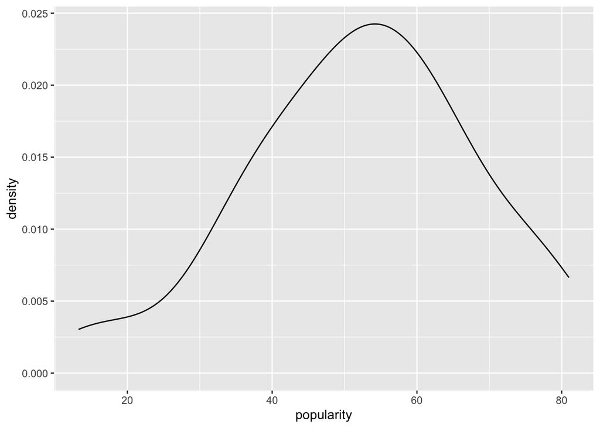

```r
ggplot(artist_means, aes(x = popularity)) +
  geom_density()
```

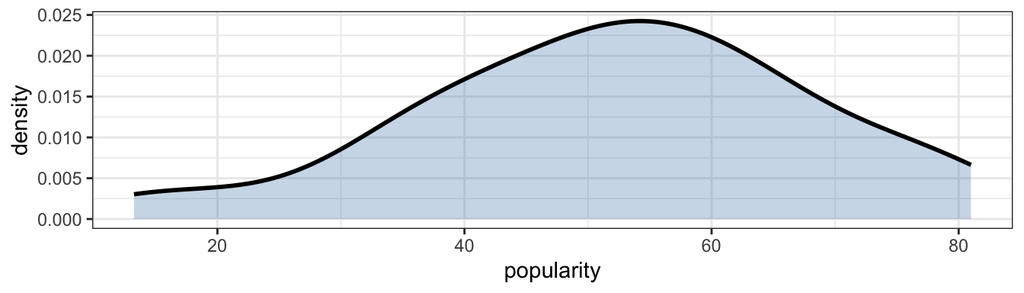

```r
ggplot(artist_means, aes(x = popularity)) +
  geom_density(linewidth = 1, fill = "steelblue", alpha = .3) +
  theme_bw()
```

Ajustamos el modelos jerárquico. El término `(1 | artist)` indica que artista es un factor de agrupamiento (o efecto aleatorio). `prior_covariance` tiene que ver con la matriz de covarianza de los efectos aleatorios , sería el prior de $\mu_j$ y, no entiendo bien por qué, sería lo mismo que poner un prior $\mathcal{E}(1)$:

```r
spotify_hierarchical <- stan_glmer(
  popularity ~ (1 | artist),
  data = spotify, family = gaussian,
  prior_intercept = normal(50, 2.5, autoscale = TRUE),
  prior_aux = exponential(1, autoscale = TRUE),
  prior_covariance = decov(reg = 1, conc = 1, shape = 1, scale = 1),
  chains = 4, iter = 5000*2, seed = 84735)
```

Y vemos los priors:

```r
# Confirm the prior tunings
prior_summary(spotify_hierarchical)
```

```
## Priors for model 'spotify_hierarchical'
## ------
## Intercept (after predictors centered)
##   Specified prior:
##     ~ normal(location = 50, scale = 2.5)
##   Adjusted prior:
##     ~ normal(location = 50, scale = 52)
##
## Auxiliary (sigma)
##   Specified prior:
##     ~ exponential(rate = 1)
##   Adjusted prior:
##     ~ exponential(rate = 0.048)
##
## Covariance
##  ~ decov(reg. = 1, conc. = 1, shape = 1, scale = 1)
## ------
## See help('prior_summary.stanreg') for more details
```

Podemos ver el diagnóstico sobre los 47 parámetros (44 $\mu_j$, $\mu$, $\sigma_y$ y $\sigma_\mu$):

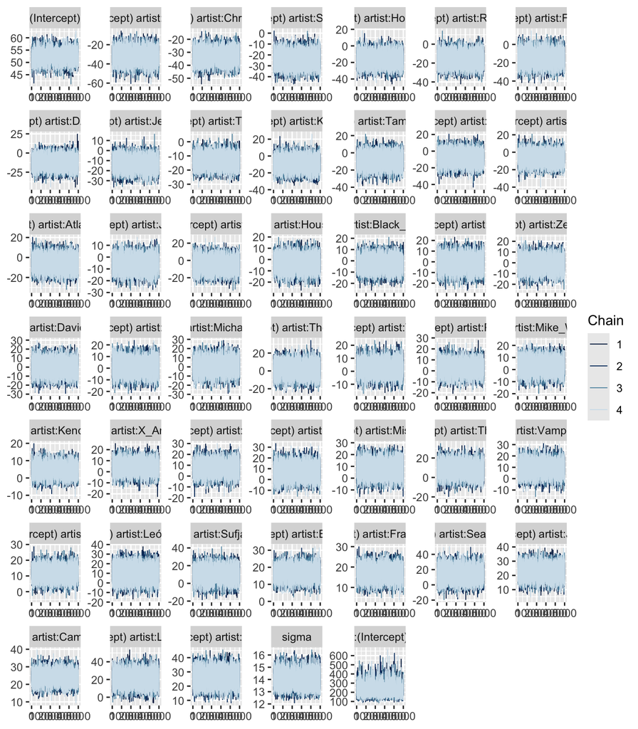

```r
mcmc_trace(spotify_hierarchical)
```

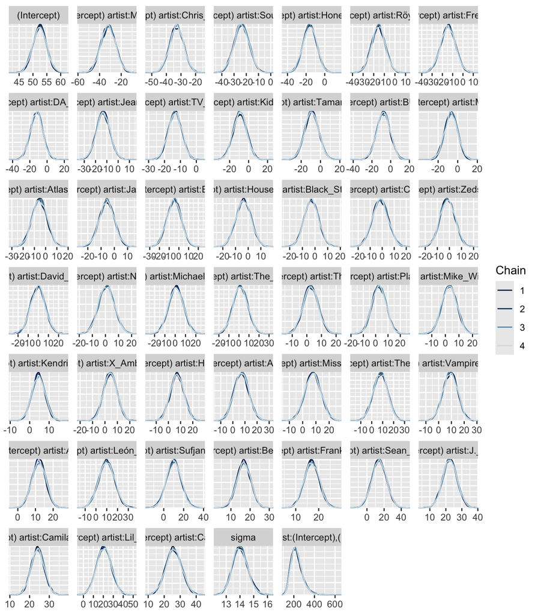

```r
mcmc_dens_overlay(spotify_hierarchical)
```

```r
neff_ratio(spotify_hierarchical)
```

```
##                              (Intercept)
##                                  0.17855
##              b[(Intercept) artist:Mia_X]
##                                  0.77280
##      b[(Intercept) artist:Chris_Goldarg]
##                                  0.51375
##          b[(Intercept) artist:Soul&Roll]
##                                  0.66455
##         b[(Intercept) artist:Honeywagon]
##                                  0.79880
##           b[(Intercept) artist:Röyksopp]
##                                  0.75600
##          b[(Intercept) artist:Freestyle]
##                                  0.80445
##           b[(Intercept) artist:DA_Image]
##                                  0.81100
##          b[(Intercept) artist:Jean_Juan]
##                                  0.64785
##           b[(Intercept) artist:TV_Noise]
##                                  0.41910
##          b[(Intercept) artist:Kid_Frost]
##                                  0.83115
##      b[(Intercept) artist:Tamar_Braxton]
##                                  0.84595
##              b[(Intercept) artist:BUNT.]
##                                  0.87730
##                b[(Intercept) artist:MTK]
##                                  0.74510
##       b[(Intercept) artist:Atlas_Genius]
##                                  0.68040
##           b[(Intercept) artist:Jazzinuf]
##                                  0.62940
##              b[(Intercept) artist:Elisa]
##                                  0.79290
##      b[(Intercept) artist:House_Of_Pain]
##                                  0.68000
## b[(Intercept) artist:Black_Stone_Cherry]
##                                  0.65250
##              b[(Intercept) artist:C-Kan]
##                                  0.77330
```

[output cut: 39 more lines]

```
##                                  0.28955
##      b[(Intercept) artist:Sean_Kingston]
##                                  0.93845
##            b[(Intercept) artist:J._Cole]
##                                  0.49660
##     b[(Intercept) artist:Camila_Cabello]
##                                  0.30635
##          b[(Intercept) artist:Lil_Skies]
##                                  0.84850
##             b[(Intercept) artist:Camilo]
##                                  0.58210
##                                    sigma
##                                  0.84050
##    Sigma[artist:(Intercept),(Intercept)]
##                                  0.19085
```

```r
rhat(spotify_hierarchical)
```

```
##                              (Intercept)
##                                1.0008220
##              b[(Intercept) artist:Mia_X]
##                                1.0001391
##      b[(Intercept) artist:Chris_Goldarg]
##                                0.9998651
##          b[(Intercept) artist:Soul&Roll]
##                                1.0002406
##         b[(Intercept) artist:Honeywagon]
##                                1.0001168
##           b[(Intercept) artist:Röyksopp]
##                                1.0000496
##          b[(Intercept) artist:Freestyle]
##                                1.0000014
##           b[(Intercept) artist:DA_Image]
##                                1.0000454
##          b[(Intercept) artist:Jean_Juan]
##                                1.0000395
##           b[(Intercept) artist:TV_Noise]
##                                1.0000438
##          b[(Intercept) artist:Kid_Frost]
##                                1.0000608
##      b[(Intercept) artist:Tamar_Braxton]
##                                0.9999553
##              b[(Intercept) artist:BUNT.]
##                                0.9999160
##                b[(Intercept) artist:MTK]
##                                1.0005003
##       b[(Intercept) artist:Atlas_Genius]
##                                1.0001059
##           b[(Intercept) artist:Jazzinuf]
##                                0.9999770
##              b[(Intercept) artist:Elisa]
##                                0.9999609
##      b[(Intercept) artist:House_Of_Pain]
##                                1.0000742
## b[(Intercept) artist:Black_Stone_Cherry]
##                                0.9999885
##              b[(Intercept) artist:C-Kan]
##                                0.9999436
```

[output cut: 39 more lines]

```
##                                1.0006008
##      b[(Intercept) artist:Sean_Kingston]
##                                1.0000611
##            b[(Intercept) artist:J._Cole]
##                                1.0001423
##     b[(Intercept) artist:Camila_Cabello]
##                                1.0005154
##          b[(Intercept) artist:Lil_Skies]
##                                0.9999641
##             b[(Intercept) artist:Camilo]
##                                1.0000691
##                                    sigma
##                                1.0001962
##    Sigma[artist:(Intercept),(Intercept)]
##                                1.0007369
```

Y también la posterior:

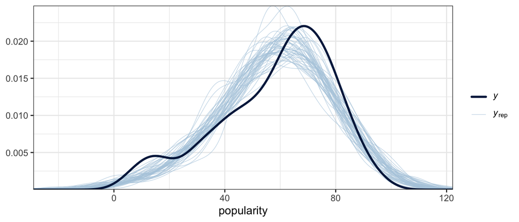

```r
pp_check(spotify_hierarchical) +
  xlab("popularity") +
  theme_bw()
```

Podemos ver también las posteriores por artista:

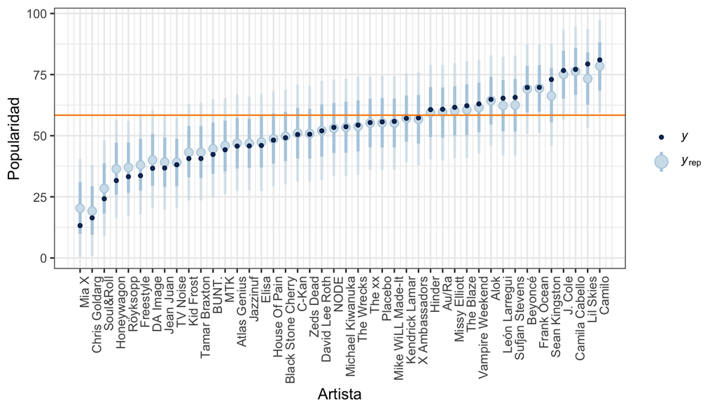

```r
set.seed(84735)
predictions_hierarchical <- posterior_predict(spotify_hierarchical,
                                              newdata = artist_means)

# Posterior predictive plots
ppc_intervals(artist_means$popularity, yrep = predictions_hierarchical,
              prob_outer = 0.80) +
  ggplot2::scale_x_continuous(labels = artist_means$artist,
                              breaks = 1:nrow(artist_means)) +
  theme_bw() +
  xaxis_text(angle = 90, hjust = 1) +
  geom_hline(yintercept = 58.4, color = "darkorange")  +
  labs(x = "Artista", y = "Popularidad")
```